# Лабораторная работа №4

# Системы линейных уравнений

## 1. Решить СЛАУ с двумя неизвестными.

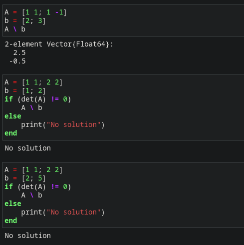

Рисунок 30: Задания a, b, c

# Системы линейных уравнений

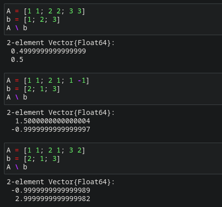

Рисунок 31: Задания d, e, f

# Системы линейных уравнений

## 2. Решить СЛАУ с тремя неизвестными.

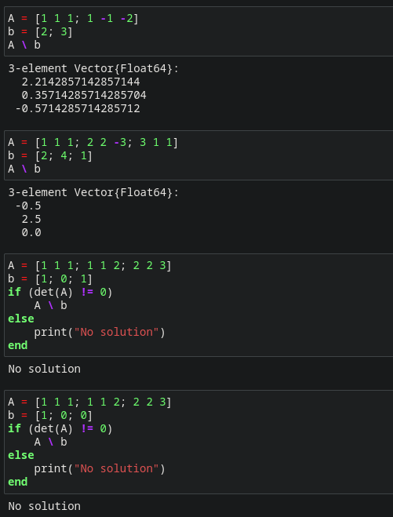

Рисунок 32: Задания a, b, c, d

# Операции с матрицами

## 1. Приведите приведённые ниже матрицы к диагональному виду.

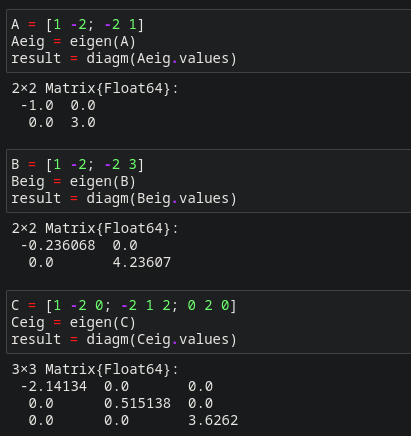

Рисунок 33: Задание 1

# Операции с матрицами

## 2. Вычислите.

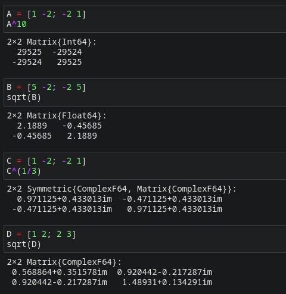

Рисунок 34: Задание 2

# Операции с матрицами

## 3. Найдите собственные значения матрицы $A$.

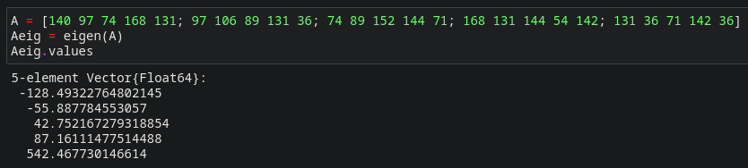

Рисунок 35: Собственные значения матрицы $A$

# Операции с матрицами

Создайте диагональную матрицу из собственных значений матрицы $A$.

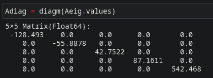

Рисунок 36: Диагональная матрица из собственных значений матрицы $A$

# Операции с матрицами

Создайте нижнедиагональную матрицу из матрицы $A$.

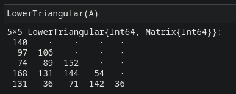

Рисунок 37: Нижнедиагональная матрица из матрицы $A$

# Операции с матрицами

Оцените эффективность выполняемых операций.

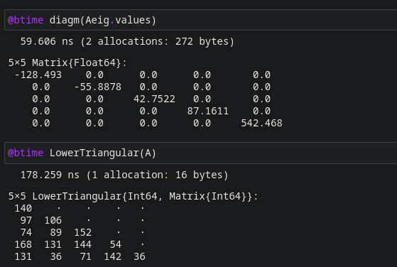

Рисунок 38: Оценка эффективности выполняемых операций

# Линейные модели экономики

Линейная модель экономики может быть записана как СЛАУ

$$x - Ax = y,$$

где элементы матрицы $A$ и столбца $y$ – неотрицательные числа. По своему смыслу в экономике элементы матрицы $A$ и столбцов $x, y$ не могут быть отрицательными числами.

1. Матрица $A$ называется продуктивной, если решение $x$ системы при любой неотрицательной правой части $y$ имеет только неотрицательные элементы $x_i$. Используя это определение, проверьте, являются ли матрицы продуктивными.

# Линейные модели экономики

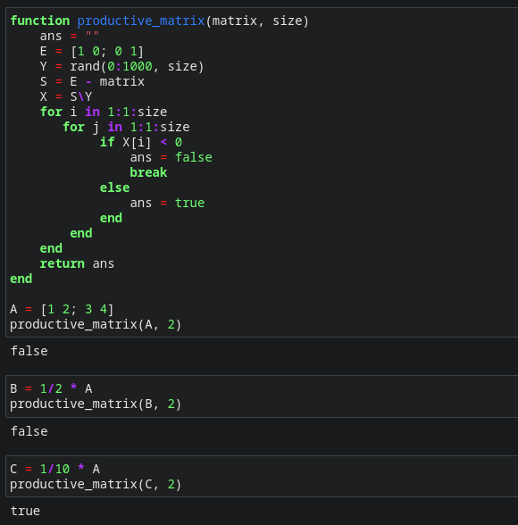

Рисунок 39: Задание 1

# Линейные модели экономики

2. Критерий продуктивности: матрица $A$ является продуктивной тогда и только тогда, когда все элементы матрицы

$$(E - A)^{-1}$$

являются неотрицательными числами. Используя этот критерий, проверьте, являются ли матрицы продуктивными.

# Линейные модели экономики

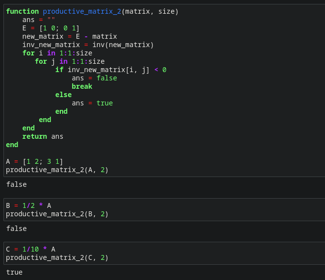

Рисунок 40: Задание 2

# Линейные модели экономики

3. Спектральный критерий продуктивности: матрица $A$ является продуктивной тогда и только тогда, когда все её собственные значения по модулю меньше 1. Используя этот критерий, проверьте, являются ли матрицы продуктивными.

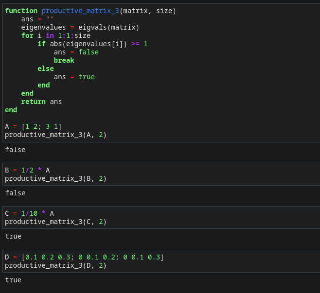

Рисунок 41: Задание 3

# Выводы

Изучены возможности специализированных пакетов Julia для выполнения и оценки эффективности операций над объектами линейной алгебры.